# Does changes in the price of salmon affect salmon producing companies?

### What is the optimal price?

```
Call:
lm(formula = Volume_tons ~ Price_per_kg_NOK + I(Price_per_kg_NOK^2),
    data = marine_salmar_laksepris)

Residuals:
    Min      1Q  Median      3Q     Max
-9028.7 -2214.5  -249.6  2453.0 10484.7

Coefficients:
                       Estimate Std. Error t value Pr(>|t|)
(Intercept)           2361.9234  1015.3739   2.326   0.0202 *
Price_per_kg_NOK       482.5436    47.7640  10.103  < 2e-16 ***
I(Price_per_kg_NOK^2)   -4.2488     0.5184  -8.195 6.33e-16 ***
---
Signif. codes:  0 '***' 0.001 '**' 0.01 '*' 0.05 '.' 0.1 ' ' 1

Residual standard error: 3177 on 1205 degrees of freedom
Multiple R-squared:  0.1802,    Adjusted R-squared:  0.1788
F-statistic: 132.4 on 2 and 1205 DF,  p-value: < 2.2e-16
```

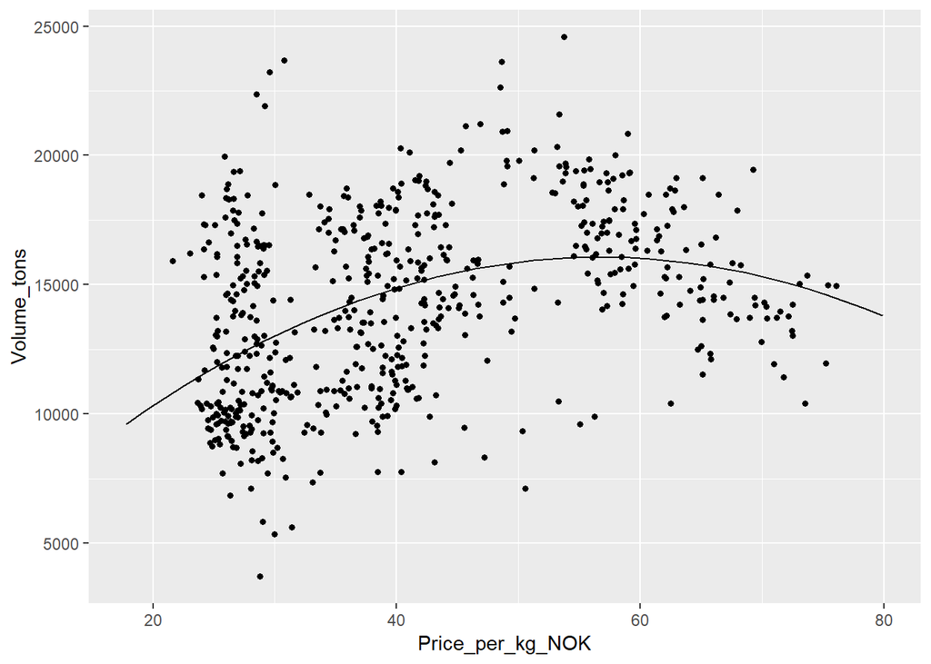

#### Optimal price in number

```
Price_per_kg_NOK
        56.78596
```

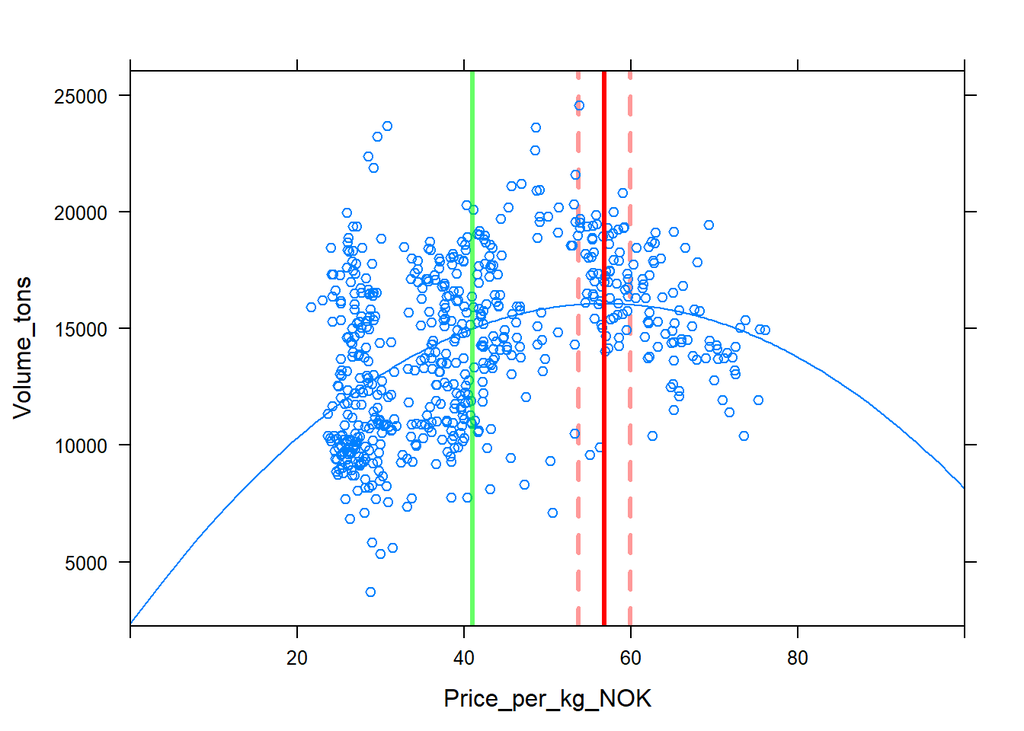

We can calculate the optimal pricing for the firms which will maximize profit. Using price and volume (supply=demands). First we have to make a linear regression between price and volume using a second degree formula. This is so we can find the maximal point and where the volume starts to decrease as the price increases, which we couldn’t see using the regular linear and non linear from above. To find the optimal price to maximize profit, we will have to derivative the function with respects to price and set the equation equal to zero. Above we can see the optimal price for maximizing value for profit. We can also calculate the optimal level where the price will give best value using a correlation level of 0.05. This is shown in the graph above, where the optimal level is between the red dot lines. The green line is the mean result.

### What is the optimal volume?

```
Call:
lm(formula = Price_per_kg_NOK ~ Volume_tons + I(Volume_tons^2),
    data = marine_salmar_laksepris)

Residuals:
    Min      1Q  Median      3Q     Max
-22.948  -8.131  -2.201   8.243  38.177

Coefficients:
                   Estimate Std. Error t value Pr(>|t|)
(Intercept)      -2.798e+00  4.882e+00  -0.573    0.567
Volume_tons       4.966e-03  7.038e-04   7.057 2.87e-12 ***
I(Volume_tons^2) -1.250e-07  2.450e-08  -5.100 3.94e-07 ***
---
Signif. codes:  0 '***' 0.001 '**' 0.01 '*' 0.05 '.' 0.1 ' ' 1

Residual standard error: 12.46 on 1205 degrees of freedom
Multiple R-squared:  0.1528,    Adjusted R-squared:  0.1514
F-statistic: 108.6 on 2 and 1205 DF,  p-value: < 2.2e-16
```

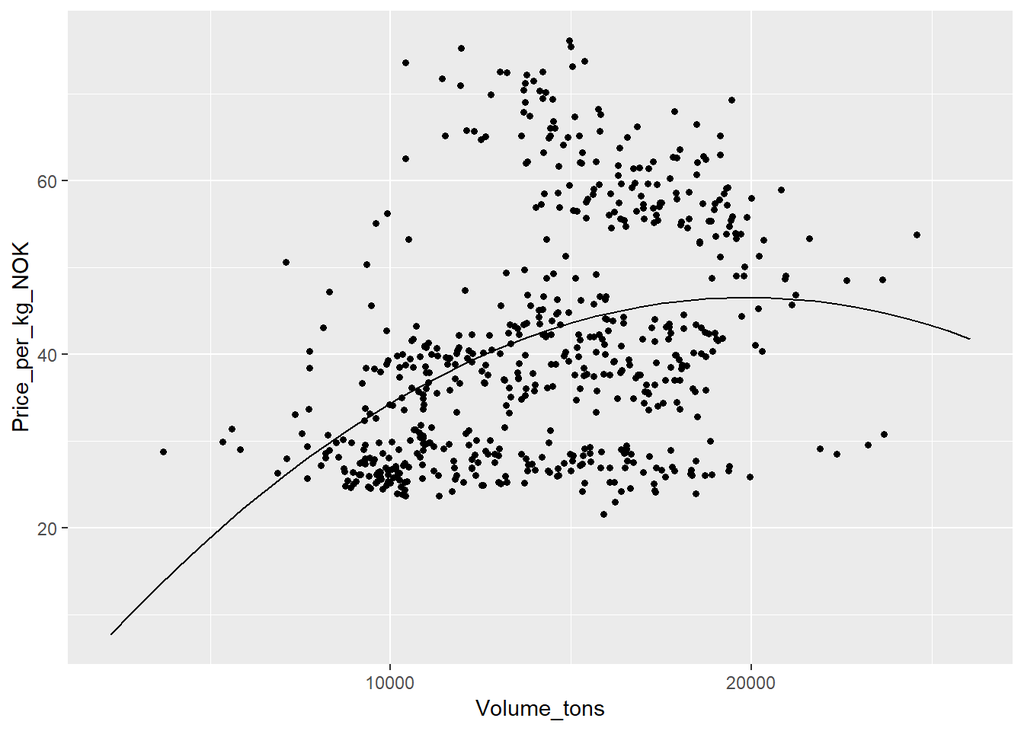

#### Optimal volume in number

```
Volume_tons
   19870.87
```

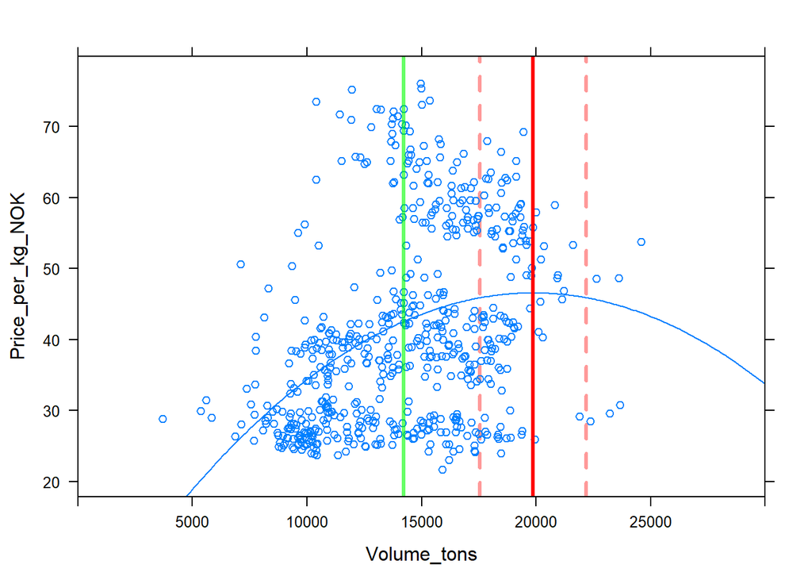

Using the same method we can also calculate the optimal volume this firms should be selling. The optimal current volume as shown above, we can also calculate the optimal level which we can see in the graph above.

## Some concluding words

We have displayed the development of the salmon price and the stock prices of Salmar and Marine harvest, during the past years. Furthermore we did find a correlation between the salmon price and the stock value of Salmar and Marine harvest. And this is as deep this analysis goes.